# Vecchia Approximation

2022-12-12

Load packages:

```r
library(GpGp)
library(monomvn)
library(Matrix)
library(SparseM)
library(vecchia)
```

We will use $n = 300,$ although the approximation ideas here are meant for much larger $n$. The code below defines and plots $t_1,\dots, t_n \in [0,1]^2$. Row $i$ of $\texttt{locs}$ contains the $(x,y)$ coordinates of $t_i$.

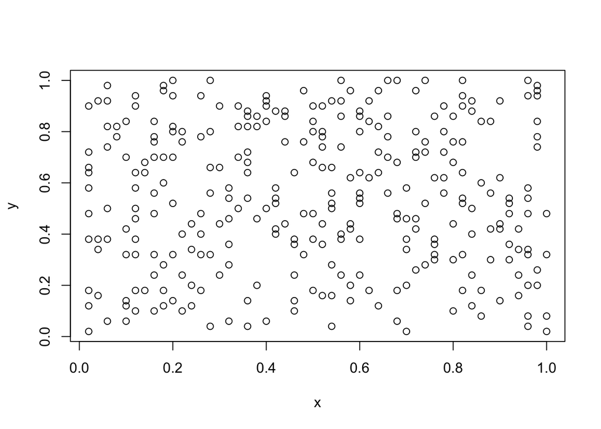

```r
nvec <- c(50,50)
n <- prod(nvec)
locs <- as.matrix(expand.grid((1:nvec[1])/nvec[1],(1:nvec[2])/nvec[2]))
locs <- locs[sample(n, 300),]
n <- nrow(locs)
plot( locs[,1], locs[,2], ylab = "y", xlab = "x")
```

Next, we generate a covariance matrix
$$\Sigma_{ij} = C(t_i,t_j)$$
We use the exponential covariance
$$C(t_1,t_2) =
\sigma^2\exp(-\lVert t_1 - t_2\rVert/\alpha)$$
with
$$(\sigma^2 , \alpha) = (1,0.4)$$

```r
covparms <- c(1,0.4,0)
Sigma <- exponential_isotropic( covparms, locs )
```

We define and visualize a sparsity pattern using the nearest neighbor approach and construct the Vecchia approximation based on this sparsity pattern.

```r
m = 45
NNarray <- find_ordered_nn(locs, m)
system.time(GammaNN <- vecchia_Linv(covparms, "exponential_isotropic", locs, NNarray))
```

```
##    user  system elapsed
##   0.009   0.000   0.009
```

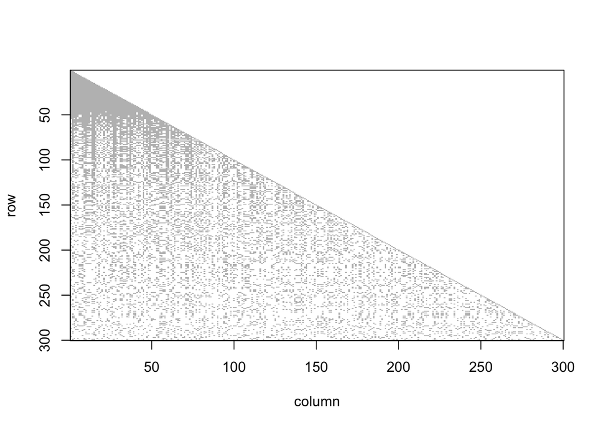

```r
image(as.matrix.csr(expandm(GammaNN, NNarray)))
```

We evaluate the approximation using KL-divergence

```r
SigmaNN <- solve(t(expandm(GammaNN, NNarray))%*%expandm(GammaNN, NNarray) )
log10(kl.norm(rep(0,n), Sigma, rep(0,n), SigmaNN, quiet<-FALSE))
```

```
## [1] -2.576519
```

Next, we construct the Vecchia approximation with a dynamically obtained sparsity pattern. First we use DyanmicF, which is slow because it searches over a lot of things.

```r
NNarray2 <- find_ordered_nn(locs, n)
system.time(obj <- FSPAI(get("exponential_isotropic"), covparms, Sigma, NNarray2, locs, m ))
```

```
##    user  system elapsed
##   9.133   0.093   9.251
```

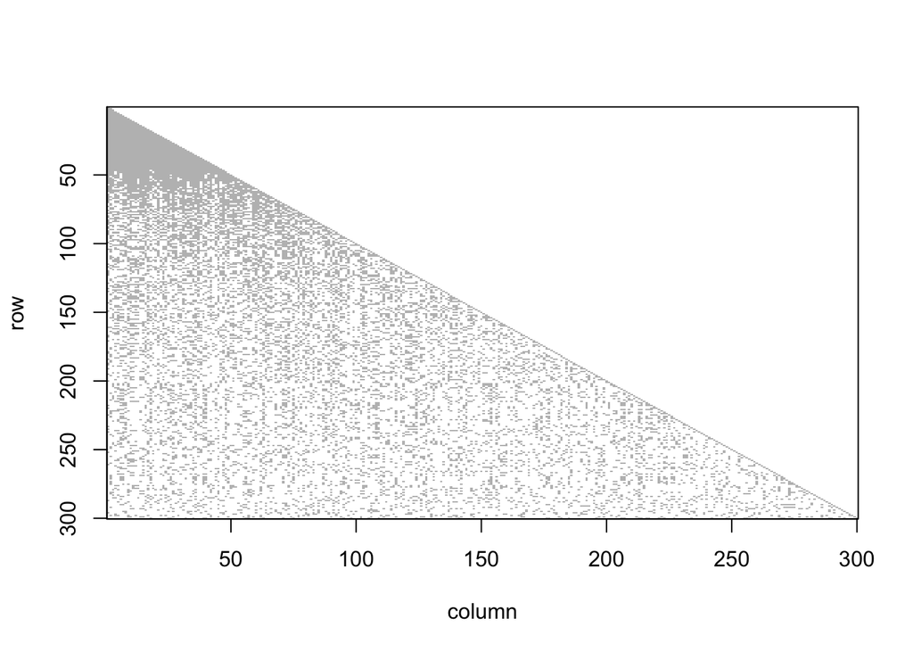

```r
Gamma_DynamicF <- obj$Linv
NNarrayF <- obj$NNarray
image(as.matrix.csr(expandm(Gamma_DynamicF, NNarrayF)))
```

The Kl-divergence is lower than before (approximation is better)

```r
Sigma_DynmaicF <-  solve(t(expandm(Gamma_DynamicF, NNarrayF))%*%expandm(Gamma_DynamicF, NNarrayF) )
log10(kl.norm(rep(0,n), Sigma, rep(0,n), Sigma_DynmaicF, quiet<-FALSE))
```

```
## [1] -3.493619
```

Now we use DyanmicS, which is faster than DynamicF because it searches over less things

```r
NNarray2 <- find_ordered_nn(locs, round(1.5*m))
system.time(obj <- FSPAI(get("exponential_isotropic"), covparms, Sigma, NNarray2, locs, m ))
```

```
##    user  system elapsed
##   3.537   0.019   3.556
```

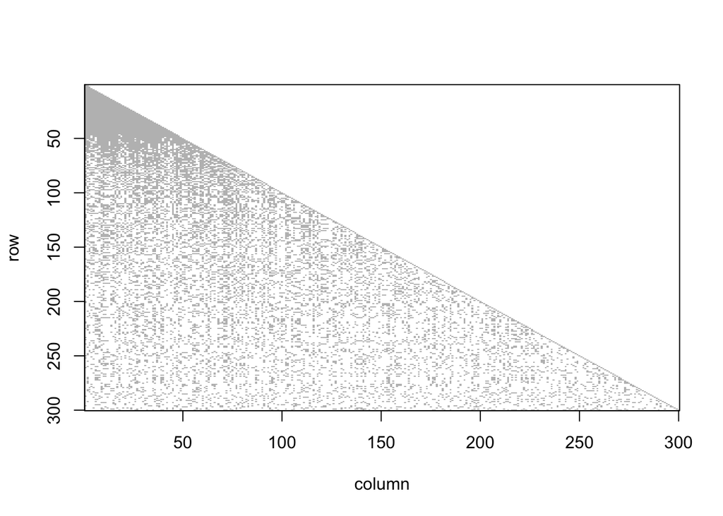

```r
Gamma_DynamicS <- obj$Linv
NNarrayS <- obj$NNarray
image(as.matrix.csr(expandm(Gamma_DynamicS, NNarrayS)))
```

```r
Sigma_DynmaicS <- solve(t(expandm(Gamma_DynamicS, NNarrayS))%*%expandm(Gamma_DynamicS, NNarrayS) )
log10(kl.norm(rep(0,n), Sigma, rep(0,n), Sigma_DynmaicS, quiet <-FALSE))
```

```
## [1] -3.215911
```